# homework

22062

2022/11/25

# Overview

This is my homework for the Statistical Computation course of 2022.

# HW0

## Question

Use knitr to produce at least 3 examples(text,figures,tables).

## Answer

text:

```r
mytext = "hello R!"
print(mytext)
```

```
## [1] "hello R!"
```

figures:

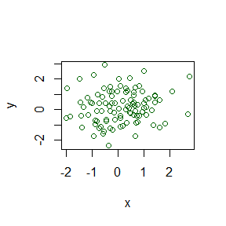

```r
x <- rnorm(100)
y <- rnorm(100)
plot(x,y,col = "darkgreen")
```

tables:

```r
library(kableExtra)
dt <- state.x77[1:10,]
kable(dt)
```

|  | Population | Income | Illiteracy | Life Exp | Murder | HS Grad | Frost | Area |
| --- | --- | --- | --- | --- | --- | --- | --- | --- |
| Alabama | 3615 | 3624 | 2.1 | 69.05 | 15.1 | 41.3 | 20 | 50708 |
| Alaska | 365 | 6315 | 1.5 | 69.31 | 11.3 | 66.7 | 152 | 566432 |
| Arizona | 2212 | 4530 | 1.8 | 70.55 | 7.8 | 58.1 | 15 | 113417 |
| Arkansas | 2110 | 3378 | 1.9 | 70.66 | 10.1 | 39.9 | 65 | 51945 |
| California | 21198 | 5114 | 1.1 | 71.71 | 10.3 | 62.6 | 20 | 156361 |
| Colorado | 2541 | 4884 | 0.7 | 72.06 | 6.8 | 63.9 | 166 | 103766 |
| Connecticut | 3100 | 5348 | 1.1 | 72.48 | 3.1 | 56.0 | 139 | 4862 |
| Delaware | 579 | 4809 | 0.9 | 70.06 | 6.2 | 54.6 | 103 | 1982 |
| Florida | 8277 | 4815 | 1.3 | 70.66 | 10.7 | 52.6 | 11 | 54090 |
| Georgia | 4931 | 4091 | 2.0 | 68.54 | 13.9 | 40.6 | 60 | 58073 |

```r
# clear all
rm(list = ls())
```

# HW1

## exercise 3.3

The Pareto(a,b) distribution has cdf
$$F\left ( x \right ) =1-\left (
\frac{b}{x} \right )^a, x\ge b> 0,a> 0$$
Derive the probability inverse transformation $F^{-1}(U)$ and use the inverse transform method to simulate a random sample from the Pareto(2,2) distribution. Graph the density histogram of sample with the Pareto(2,2) density superimposed for comparison.

## Answer

According to chap02.pdf, my solution is as follows.

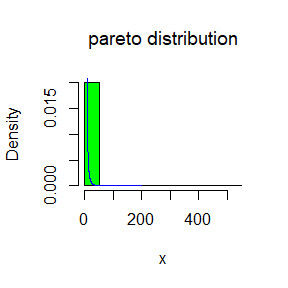

```r
invtr_pareto = function(a,b,n){      #inverse transformation for pareto(a,b)
  number = n
  u = runif(number)     #uniform(0,1)
  x = (1/(1-u))^(1/a)*b      #inversed function for F()
  hist(x,prob = TRUE,main = expression( "pareto distribution" ),col = "green" )
  y = seq(0, 200, 0.1)
  lines(y,b^a*a*y^(-a-1),col="blue")   #density corresponding to F()
}

invtr_pareto(a=2,b=2,n=5000)
```

## exercise 3.7

Write a function to generate a random sample of size n from the Beta(a,b) distribution by the acceptance-rejection method. Generate a random sample size 1000 from Beta(3,2) distribution. Graph the histogram of the sample with the theoretical Beta(3,2) density superimposed.

## Answer

maximum for pdf f(x) occurs at $\frac{\alpha -1}{\alpha + \beta -2}$ if there is a maximum for it. Take this maximum value as t(x) and t(x) majorizes f(x).So we can perform Acceptance-rejection algorithm as follows:

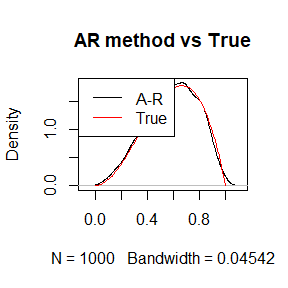

```r
beta_pdf = function(x,a,b){   #pdf for beta distribution
  x^(a-1)*(1-x)^(b-1)/beta(a,b)
}

ar_beta = function(a,b,n){
  k = 0   #counter for acception
  j = 0   #iterations
  x = numeric(0)   #initiation

  max_p = (a-1)/(a+b-2)   # max point, if it exists
  max_v = beta_pdf(max_p,a,b)

  while(k<n){
    u = runif(1)
    j=j+1
    y = runif(1)    # random variate from g()
    if( beta_pdf(y,a,b)/max_v>u ){   # we accept it
      k = k+1
      x[k] = y
    }
  }

  #make a plot:
  plot(density(x), main = bquote("AR method vs True"))
  this.range <- seq(0, 1, 0.01)
  f <- function(x) beta_pdf(x,a,b)
  lines(this.range,f(this.range), col="red")
  legend("topleft", legend = c("A-R", "True"), col=c("black", "red"), lty=1)

}

ar_beta(3,2,1000)
```

## exercise 3.12

Simulate a continuous Exponential-Gamma mixture. Suppose that the rate parameter $\Lambda$ has $Gamma(r,\beta )$ distribution and Y has Exp($\Lambda$) distribution. That is,
$$(Y|\Lambda = \lambda )\sim f_{Y}\left (
y|\lambda \right )=\lambda e^{-\lambda y}$$
Generate 1000 random observations from this mixture with r=4 and $\beta$=2.

## Answer

According to chap02.pdf, my solution is as follows.

```r
exp_gam_mix = function(n,r,beta){   # my generator
  lambda = rgamma(n,r,beta)
  x = rexp(n,lambda)
  x
}

x = exp_gam_mix(n=1e3,r=4,beta=2)
# observations generated.
```

## exercise 3.13

It can be shown that the mixture in Exercise 3.12 has a Pareto distribution with cdf
$$F(y)=1-\left(\frac{\beta}{\beta+y}\right)^r,\quad
y\geq0.$$
(this is an alternative parameterization of the Pareto cdf given in Exercise 3.3.) Generate 1000 random observations from the mixture with $r=4$ and $\beta=2$. Compare the empirical and theoretical (Pareto) distributions by graphing the density histogram of the sample and superimposing the Pareto density curve.

## Answer

According to chap02.pdf, my solution is as follows.

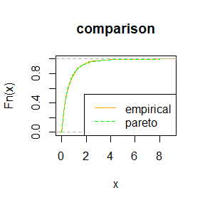

```r
bet=2;r=4
x = exp_gam_mix(n=1e3,r=4,bet=2)
plot(ecdf(x),xlim=c(-0.1,9),col="orange",lty=1,main="comparison")
y = seq(0,8,.01)
lines(y,1-(bet/(bet+y))^r,col="green",lty=2)
legend("bottomright", legend = c("empirical", "pareto"), col=c("orange", "green"), lty=c(1,2))
```

```r
# clear all
rm(list = ls())
```

# HW2

## exercise 1

For $n=10^4,2\times10^4,4\times10^4,6\times10^4,8\times10^4$, apply the fast sorting algorithm to randomly permuted numbers of 1,…,n. Calculate computation time averaged over 100 simulations, denoted by $a_n$.

## Answer

According to chap03.pdf, my solution is as follows.

```r
my_qsort = function(x){   # function for recursively quick sort.
  num = length(x)
  if(num==0||num==1){
    return(x)
  }
  else{
    a = x[1]
    y = x[-1]
    left = y[y<a]
    right = y[y>=a]
    return(c(my_qsort(left),a,my_qsort(right)))}
}

numbers = c(1e4,2*1e4,4*1e4,6*1e4,8*1e4)    # how many numbers
an = numeric(5)       # averged runtime for length n
i = 1
print("Here is the result of runtimes:")
```

```
## [1] "Here is the result of runtimes:"
```

```r
for(number in numbers){
  runtime = numeric(100)
  for(j in 1:100){
    mysample = sample(1:number)     # get randomly permuted numbers
    runtime[j] = system.time(my_qsort(mysample))[1]
  }
  an[i]=mean(runtime)
  print(paste("  runtime for numbers of length",number,"is",an[i]))
  i=i+1
}
```

```
## [1] "  runtime for numbers of length 10000 is 0.0187"
## [1] "  runtime for numbers of length 20000 is 0.0419000000000007"
## [1] "  runtime for numbers of length 40000 is 0.0856999999999999"
## [1] "  runtime for numbers of length 60000 is 0.1332"
## [1] "  runtime for numbers of length 80000 is 0.1762"
```

Regress $a_n$ on $t_n:=n\log n$, and graphically show the results(Scatter plot and regression line).

## Answer

My solution and plot with regression line are as follows.

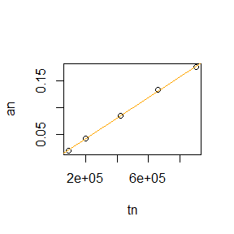

```r
tn = numbers*log(numbers)
mymodel = lm(an ~ tn)
plot(tn,an)
abline(mymodel,col = "orange")    # add regression line
```

## exercise 5.6

In Example 5.7 the control variate approach was illustrated for Monte Carlo integration of
$$\theta = \int_{0}^{1}
e^x dx$$
Now we consider the antithetic variate approach. Compute $Cov(e^U,e^{1-U})$ and $Var(e^U+e^{1-U})$, where $U\sim {\rm Uniform}(0,1)$. What is the percent reduction in variance of $\hat{\theta}$ that can be achieved using antithetic variates (compared with simple MC)?

## Answer

$$\mathbb{E}\left ( e^{U} \right
)=\int_{0}^{1}e ^udu= e-1$$
Similarly, we have:
$$\mathbb{E}\left ( e^{1-U} \right )= e-1$$
$$\mathbb{E}\left ( e^{U}e^{1-U} \right
)=\mathbb{E}\left ( e \right ) =e$$
Thus we can compute:
$$Cov(e^{U},e^{1-U})=\mathbb{E}\left ( e^{U}e^{1-U}
\right )-\mathbb{E}\left ( e^{U} \right )\mathbb{E}\left ( e^{1-U}
\right )=-e^2+3e-1$$
$$Var(e^{U}+e^{1-U})=\mathbb{E}\left ( e^{U}e^{1-U}
\right )^2-(\mathbb{E}\left ( e^{U}e^{1-U} \right
))^2=-3e^2+10e-5$$
Meanwhile,for simple MC:
$$Var(e^U)=\frac{e^2-1}{2}-(e-1)^2$$
So we can compute the percent reduction compared with simple MC:
$$\frac{Var(e^U)-\frac{Var(e^{U}+e^{1-U})}{4}}{Var(e^U)}=0.983835=98.3835\%$$

## exercise 5.7

Refer to Exercise 5.6. Use a Monte Carlo simulation to estimate $\theta$ by the antithetic variate approach and by the simple Monte Carlo method. Compute an empirical estimate of the percent reduction in variance using the antithetic variate. Compare the result with the theoretical value from Exercise 5.6.

## Answer

We are about to estimate $\theta =\int_{0}^{1}e^xdx$,
the simple Monte-Carlo estimator is:
$$\widehat{\theta
}=\frac{1}{m}\sum_{j=1}^{m}e^{U_{j}} ,U_{j}\sim Uniform(0,1)$$
and The antithetic variable estimator is:
$$\widehat{\theta
}=\frac{1}{m}\sum_{j=1}^{m/2}{e^{U_{j}}+e^{1-U_{j}}} ,U_{j}\sim
Uniform(0,1)$$
So the solution is as follows:

```r
antitheticV_mc = function(nsim = 1e5) {    # antithetic variate approach,nsim is the number of simulation.
  u = runif(nsim/2)
  v = 1 - u
  u = c(u, v)
  g = exp(u)
  mean(g)
}
simple_mc = function(nsim = 1e5) {    # simple monte carlo
  u = runif(nsim)
  g <- exp(u)
  mean(g)
}

n_sim = 1e4
MC1 <- MC2 <- numeric(n_sim)
for (i in 1:n_sim) {
  MC1[i] <- simple_mc(nsim=n_sim)
  MC2[i] <- antitheticV_mc(nsim=n_sim)
}

(var(MC1) - var(MC2))/var(MC1)
```

```
## [1] 0.9690738
```

The result of simulation is a little smaller than what we’ve previously computed.

```r
# clear all
rm(list = ls())
```

# HW3

## exercise 5.13

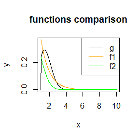

```r
g = function (x) {
  x^2/sqrt(2*pi)*exp(-x^2/2)*(x>1)
}
xseq = seq(1,10,0.01)
yg = g(xseq)
y1 = exp(-xseq)
y2 = dnorm(xseq)

# to draw the density functions:
ymax = max(c(yg,y1,y2))
plot(xseq,yg,type="l",xlim = c(1,10),ylim=c(0,ymax),main="functions comparison",xlab="x",ylab="y")
lines(xseq,y1,col="orange")
lines(xseq,y2,col="green")
legend("topright",legend = c("g","f1","f2"),col=c("black","orange","green"),lty=1)
```

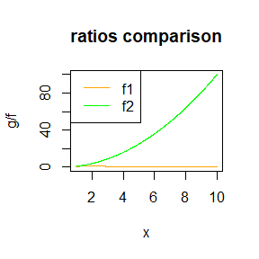

```r
# to draw the ratios:
ymax = max(c(yg/y1,yg/y2))
plot(xseq,yg/y1,type="l",col="orange",xlim = c(1,10),ylim=c(0,ymax),main="ratios comparison",xlab="x",ylab="g/f")
lines(xseq,yg/y2,col="green")
legend("topleft",legend = c("f1","f2"),col=c("orange","green"),lty=1)
```

According to the density function and ratio plots above, we can guess $f_1$ is closer to g and therefore should produce the smaller variance by importance sampling.

```r
m=10000
theta_hat = se = numeric(2)

x1=rexp(m,1)    # importance sampling for f1
fg1 = g(x1)/exp(-x1)
theta_hat[1] = mean(fg1);se[1] = sd(fg1)

x2=rnorm(m)   # importance sampling for f2
fg2 = g(x2)/dnorm(x2)
theta_hat[2] = mean(fg2);se[2] = sd(fg2)

t = rbind(theta_hat,se)
colnames(t) = c("f1","f2")
print(t)
```

```
##                  f1        f2
## theta_hat 0.3999701 0.4105342
## se        0.5861645 1.1612868
```

Simulation also indicates smaller variance of $f_1$.

## exercise 5.15

Obtain the stratified importance sampling estimate in Example 5.13 and compare it with results of Example 5.10.

$\frac{g(x)}{f_3(x)}=\frac{1-e^{-1}}{1+x^2}$In inverse transform method we have $log(1 - u(1 - exp(-1)))$, so in stratified importance sampling we divide the interval [0,1] into subintervals $log(1 - a(1 - exp(-1)))$.

```r
M = 1e5;k = 5
r = M/k #replicates per stratum
N = 50
T2_k = numeric(k)
stra_est = numeric(N)
newfunc = function(x)  (1-exp(-1))/(1+x^2)*(x<1)*(x>0)
for (i in 1:N) {
  for(j in 1:k) {
    fk1 = -log( 1-(1-exp(-1))*(j-1)/k )
    fk2 = -log( 1-(1-exp(-1))*j/k )
    u = runif(M*(fk2-fk1))    # so there are M in total for one N.
    X = -log(exp(-fk1)-(1-exp(-1))*u/k )    # random numbers of 5*f3 in this subinterval
    T2_k[j] = mean( (1-exp(-1))/((1+X^2)*5) )
  }
  stra_est[i] = sum(T2_k)
}

mean(stra_est)
```

```
## [1] 0.5248038
```

```r
sd(stra_est)
```

```
## [1] 5.377495e-05
```

```r
# clear all
rm(list = ls())
```

# HW4

## exercise 6.4

Suppose that $X_1,...,X_n$ are a random sample from a lognormal distribution with unknown parameters. Construct a 95% confidence interval for the parameter $\mu$. Use a Monte Carlo method to obtain an empirical estimate of the confidence level.

## Answer

Here we construct the required 95% confidence interval for the parameter $\mu$ : According to this exercise, $X_1,...,X_n$ follows lognormal distribution with parameters, that is:
$$ln(X_i)\sim N(\mu,\sigma )$$
Now define $Y_i\doteq ln(X_i)\sim N(\mu,\sigma )$ Then we have:
$$\hat{\mu }
=\bar{Y} =\frac{1}{n} {\textstyle \sum_{i=1}^{n}Y_i}= \frac{1}{n}
{\textstyle \sum_{i=1}^{n}ln(X_i)}$$
and an $\alpha$ interval for $\mu$ is:
$$\overline{Y} \pm A S/\sqrt{n}=\overline{ln(X)}
\pm A S/\sqrt{n}$$
where
$$A=t_{1-\alpha
/2}(n-1),S^2=\frac{1}{n-1} {\textstyle \sum_{i=1}^{n}(Y_i-\overline{Y}
)^2}$$

Here are the functions for this exercise:

```r
# remove all before start:
rm(list=ls())

get_data = function(n,mu,sig){     # function for data generation
  x = rlnorm(n,mu,sig)
  return( x )
}

make_ucl = function(m,n,mu,sig,alpha){    # function for making confidence interval
  ucl = replicate(m,
                  expr = {
                    x = rlnorm(n,meanlog = mu,sdlog = sig)
                    y = log(x)
                    abs( sqrt(n)*(mean(y)-mu)/sd(y) )
                  }   )
  return( mean(ucl<qt(1-alpha/2,n-1)) )
}
```

Here we do the estimating:

```r
n=50
mu=0
sig=2
m=1e4
alpha=0.05
set.seed(0)
res = make_ucl(m,n,mu,sig,alpha)    # we perform simulation here.
print(paste("The obtained empirical estimate of the confidence level is",res,"this is a good result."))
```

```
## [1] "The obtained empirical estimate of the confidence level is 0.9526 this is a good result."
```

```r
rm(list=ls())
```

The obtained empirical estimate of the confidence level is 0.9526 this is a good result.

## exercise 6.8

Refer to Example 6.16. Repeat the simulation, but also compute the F test of equal variance, at significance level $\alpha \doteq 0.055$. Compare the power of the Count Five test and F test for small,medium and large sample sizes. (Recall that the F test is not applicable for non-normal distributions.)

## Answer

Here are the functions for this exercise:

```r
# remove all before start:
rm(list=ls())

count5test = function(x, y){    # function for count-five-test, from textbook
  X = x - mean(x)
  Y = y - mean(y)
  outx = sum(X > max(Y)) + sum(X < min(Y))
  outy = sum(Y > max(X)) + sum(Y < min(X))
  # return 1 (reject) or 0 (do not reject H0)
  return(as.integer(max(c(outx, outy)) > 5))
}

ftest = function(x,y,alpha){      # function for F-test
  ftp = var.test(x,y)$p.value
  return (as.integer(ftp<=alpha))
}

get_data = function(mu1,sig1,n1,mu2,sig2,n2){     # function for data generation
  x = rnorm(n1,mu1,sig1)
  y = rnorm(n2,mu2,sig2)
  return( list('x'=x,'y'=y) )
}

data_output = function(f_res,c5t_res,size_list){     # make a dataframe for result output
  mydf = as.data.frame( matrix( data = c(c5t_res,f_res),
                                nrow = length(size_list), ncol = 2,
                                byrow = FALSE
                                ) )
  colnames(mydf) = c("count5test","f_test")
  rownames(mydf) = paste0("n =",size_list)
  mydf
}
```

Here I perform simulations:

```r
set.seed(0)
m=1e4
alpha0 = 0.055
n_list = c(10,50,100,500,1000) # from small to middle to large
ft_result = c5t_result = numeric(  length(n_list)  )

i=1
for(n in n_list){       # compute results for f_test and c5test for each sample size
  sims = replicate(m,
                   expr = {
                     mydata = get_data(mu1=0,sig1=1,n1=n,mu2=0,sig2=1.5,n2=n)
                     x = mydata$x; y = mydata$y
                     c('c5t'=count5test(x,y),'ft'=ftest(x,y,alpha = alpha0))
                   }  )
  results = rowMeans(sims)
  c5t_result[i] = results[[1]]; ft_result[i] = results[[2]]
  i = i+1
}

print(data_output(ft_result,c5t_result,n_list))
```

```
##         count5test f_test
## n =10       0.1089 0.2218
## n =50       0.6582 0.8102
## n =100      0.8555 0.9831
## n =500      0.9902 1.0000
## n =1000     0.9980 1.0000
```

```r
rm(list=ls())
```

According to the results of simulation, power grows higher as sample size grows, for both count-5-test and F-test. And for a fixed sample size, power of equal variance F-test is higher than power of count-5-test.

## Question1

If we obtain the powers for two methods under a particular simulation setting with 10000 experiments: say, 0.651 for one method and 0.676 for another method. Can we say the powers are different at 0.05 level?

## Answer

No, we cannot say they are sure to be different at 0.05 level.

## Question2

What is the corresponding hypothesis test problem?

## Answer

The null hypothesis is $H_0:power1=power2$,while the alternative hypothesis is $H_1:power1\ne power2$

## Question3

Which test can we use? Z-test,two-sample t-test, paired-t test or McNemar test?Why?

## Answer

I think McNemar test is probably the best choice, because the results of powers of two methods are random variables that are not independent.They are powers of one same sample and therefore dependent.Also McNemar test does not need the distribution to be already known.

## Question3

Please provide the least necessary information for hypothesis testing.

## Answer

results of powers of 2 methods in total (denoted as 2n);  
how many results where method 1 provides accepted results while method 2 doesn’t (denoted as B); how many results where method 2 provides accepted results while method 1 doesn’t (denoted as C); then we need at least these information: n, $(B-C)^2/(B+C)$.

```r
# clear all
rm(list = ls())
```

# HW5

## Answer to exercise 7.4

```r
# remove all before start:
rm(list=ls())

bootstrap_result_get = function(x,R){   # get bootstrap
  lambda_star = numeric(R)
  for(r in 1:R){
    xstar = sample(x,replace = T)
    lambda_star[r] = 1/mean(xstar)
  }
  return(lambda_star)
}

bootstrap_result_show = function(res,x){  # output
  est.samp = 1/mean(x)
  print(c(bias.boot = mean(res)-est.samp,
        se.boot = sd(res)))
}
```

Here we do the bootstrap:

```r
# set.seed(2000)
library(boot)
mydata = aircondit$hours

R=1e4
bootstrapRes = bootstrap_result_get(mydata,R)
bootstrap_result_show(bootstrapRes,mydata)
```

```
##   bias.boot     se.boot
## 0.001255016 0.004247482
```

Another way to perform bootstrap is:

```r
x=mydata
f = function(data,inds){
  d = data[inds]
  return(1/mean(d))
}
# set.seed(2000)
bootmle=boot(x,f,R=1e4)
bootmle
```

```
##
## ORDINARY NONPARAMETRIC BOOTSTRAP
##
##
## Call:
## boot(data = x, statistic = f, R = 10000)
##
##
## Bootstrap Statistics :
##       original      bias    std. error
## t1* 0.00925212 0.001324623 0.004190542
```

Both methods show reasonable results.

## Answer to exercise 7.5

Here are the functions for this exercise:

```r
f = function(data,inds){
  d = data[inds]
  return(mean(d))
}
# set.seed(2000)
boot.obj = boot(mydata,statistic = f,R=1e4)
print(boot.ci(boot.obj,type = c("norm","basic", "perc","bca")))
```

```
## BOOTSTRAP CONFIDENCE INTERVAL CALCULATIONS
## Based on 10000 bootstrap replicates
##
## CALL :
## boot.ci(boot.out = boot.obj, type = c("norm", "basic", "perc",
##     "bca"))
##
## Intervals :
## Level      Normal              Basic
## 95%   ( 34.6, 181.9 )   ( 26.0, 169.9 )
##
## Level     Percentile            BCa
## 95%   ( 46.2, 190.2 )   ( 56.8, 223.7 )
## Calculations and Intervals on Original Scale
```

We can tell the required intervals from the output above. These intervals differ because these methods converge at different speed. Just as the lecture ppt shows, Bootstrap t confidence interval is second order accurate, but not transformation respecting. The percentile interval is transformation respecting, but only first order accurate. The standard normal confidence interval is neither transformation respecting nor second order accurate.

## Answer to exercise 7.A

According to the lecture ppt,here we generate the data, compute the required intervals and get the result as follows:

```r
rm(list=ls())
library(boot)
set.seed(1)

n = 1e1
m = 1e4
mu=0;sig=1

boot.mean = function(x,i){  mean(x[i]) }
ci.norm=ci.basic=ci.perc=matrix(NA,m,2)
for(i in 1:m){
  mydata = rnorm(n,mu,sig)
  de <- boot(data=mydata,statistic=boot.mean, R = 999)
  ci <- boot.ci(de,type=c("norm","basic","perc"))
  ci.norm[i,]<-ci$norm[2:3];ci.basic[i,]<-ci$basic[4:5]
  ci.perc[i,]<-ci$percent[4:5]
}
```

And here is my output of results:

```r
myprint = function(ci.norm,ci.basic,ci.perc){
  print("for normal interval:")
  print(paste("  empirical coverage rates:",mean(ci.norm[,1]<=mu & ci.norm[,2]>=mu),";",
               "miss on left:",mean(ci.norm[,1]>mu),";",
               "miss on right:",mean(ci.norm[,2]<mu),
               sep=" "))

  print("for basic interval:")
  print(paste("  empirical coverage rates:",mean(ci.basic[,1]<=mu & ci.basic[,2]>=mu),";",
               "miss on left:",mean(ci.basic[,1]>mu),";",
               "miss on right:",mean(ci.basic[,2]<mu),
               sep=" "))

  print("for percent interval:")
  print(paste("  empirical coverage rates:",mean(ci.perc[,1]<=mu & ci.perc[,2]>=mu),";",
               "miss on left:",mean(ci.perc[,1]>mu),";",
               "miss on right:",mean(ci.perc[,2]<mu),
               sep=" "))
}
myprint(ci.norm,ci.basic,ci.perc)
```

```
## [1] "for normal interval:"
## [1] "  empirical coverage rates: 0.8986 ; miss on left: 0.0507 ; miss on right: 0.0507"
## [1] "for basic interval:"
## [1] "  empirical coverage rates: 0.8979 ; miss on left: 0.0512 ; miss on right: 0.0509"
## [1] "for percent interval:"
## [1] "  empirical coverage rates: 0.8958 ; miss on left: 0.0522 ; miss on right: 0.052"
```

```r
mat = matrix(c(mean(ci.norm[,1]<=mu & ci.norm[,2]>=mu),mean(ci.norm[,1]>mu),mean(ci.norm[,2]<mu),
               mean(ci.basic[,1]<=mu & ci.basic[,2]>=mu),mean(ci.basic[,1]>mu),mean(ci.basic[,2]<mu),
               mean(ci.perc[,1]<=mu & ci.perc[,2]>=mu),mean(ci.perc[,1]>mu),mean(ci.perc[,2]<mu) ),
             3,3,
             byrow = TRUE)
rownames(mat) = c("for normal interval:","for basic interval:","for percent interval:")
colnames(mat) = c("empirical coverage rates","miss on left","miss on right")
library(kableExtra)
kable(as.data.frame(mat))
```

|  | empirical coverage rates | miss on left | miss on right |
| --- | --- | --- | --- |
| for normal interval: | 0.8986 | 0.0507 | 0.0507 |
| for basic interval: | 0.8979 | 0.0512 | 0.0509 |
| for percent interval: | 0.8958 | 0.0522 | 0.0520 |

```r
# remove all at the end:
rm(list=ls())
```

# HW6

## Exercise 7.8

**Solution:**

Here are the functions needed for this exercise:

```r
# remove all before start:
rm(list=ls())

get_theta = function(mydata){    # how we can get the parameter theta
  lam = eigen(cov(mydata))$values
  my_theta = lam[1]/sum(lam)

  return(my_theta)
}

get_jack = function(mytable){   # data analysis: obtain the jackknife estimates of bias and sd
  theta_Hat = get_theta(mytable)
  theta_Jack =theta_Jack2 = numeric(n)
  for(i in 1:n){
    theta_Jack[i] = get_theta(mytable[-i,])
  }

  bias_Jack = (n-1)*(mean(theta_Jack)-theta_Hat)
  se_Jack = sqrt((n-1)*mean((theta_Jack-mean(theta_Jack))^2))
  return(c(theta.hat=theta_Hat,bias.jack=bias_Jack,se.jack=se_Jack))
}
```

Here is the result of jackknife’s bias and sd of the estimated parameter.

```r
# to load the required data:
library(bootstrap)
n = nrow(scor)

# jackknife result output:
print(get_jack(scor))
```

```
##   theta.hat   bias.jack     se.jack
## 0.619115038 0.001069139 0.049552307
```

```r
# remove all at the end:
rm(list=ls())
```

## Exercise 7.11

**Solution:** At the beginning, we write the functions that we need for this exercise. The get_modErrs function here is used to get errors of each model, and it is written accordingly to the leave-one-out method, with modifications to it.

```r
# remove all before start:
rm(list=ls())


# this function is to fit models on leave-two-out samples on n-fold cross validation and compare errors:
get_modErrs = function(magnetic,chemical){
  n <- length(magnetic)
  e1 <- e2 <- e3 <- e4 <- c() # errors for each model,initialized as empty
  for (k1 in 1:(n-1)) {
    for(k2 in (k1+1):n){
    y = magnetic[-c(k1,k2)]
    x = chemical[-c(k1,k2)]

    Model1 = lm(y ~ x)
    yhat11 = Model1$coef[1] + Model1$coef[2] * chemical[k1]
    yhat12 = Model1$coef[1] + Model1$coef[2] * chemical[k2]
    e1 = c(e1,c(magnetic[k1]-yhat11, magnetic[k2]-yhat12))

    Model2 = lm(y ~ x + I(x^2))
    yhat21 = Model2$coef[1] + Model2$coef[2] * chemical[k1] + Model2$coef[3] * chemical[k1]^2
    yhat22 = Model2$coef[1] + Model2$coef[2] * chemical[k2] + Model2$coef[3] * chemical[k2]^2
    e2 = c(e2,c(magnetic[k1] - yhat21, magnetic[k2]-yhat22))

    Model3 = lm(log(y) ~ x)
    logyhat31 = Model3$coef[1] + Model3$coef[2] * chemical[k1]
    yhat31 = exp(logyhat31)
    logyhat32 = Model3$coef[1] + Model3$coef[2] * chemical[k2]
    yhat32 = exp(logyhat32)
    e3 = c(e3,magnetic[k1] - yhat31,magnetic[k2] - yhat32)

    Model4 = lm(log(y) ~ log(x))
    logyhat41 = Model4$coef[1] + Model4$coef[2] * log(chemical[k1])
    yhat41 = exp(logyhat41)
    logyhat42 = Model4$coef[1] + Model4$coef[2] * log(chemical[k2])
    yhat42 = exp(logyhat42)
    e4 = c(e4, magnetic[k1] - yhat41,magnetic[k2] - yhat42)
    }
  }

  return( list(errs=c(Model1.error=mean(e1^2), Model2.error=mean(e2^2),Model3.error=mean(e3^2), Model4.error=mean(e4^2))) )
}
```

Here is the output of results of errors for each model:

```r
library(DAAG)
results = get_modErrs(ironslag$magnetic,ironslag$chemical)
print( results$errs )
```

```
## Model1.error Model2.error Model3.error Model4.error
##     19.57227     17.87018     18.45491     20.46718
```

If we apply leave-two-out cross-validation to select the best model, according to the prediction error croterion above, Model 2, the quadratic model will fit best. Coefficients of Model2 are shown below:

```r
lm(formula = magnetic ~ chemical + I(chemical^2) ,data = ironslag)
```

```
##
## Call:
## lm(formula = magnetic ~ chemical + I(chemical^2), data = ironslag)
##
## Coefficients:
##   (Intercept)       chemical  I(chemical^2)
##      24.49262       -1.39334        0.05452
```

```r
# remove all at the end:
rm(list=ls())
```

So the selected model is:
$$\hat{Y}= 24.49262 -1.39334X+0.05452X^2$$

## Exercise 8.2

Implement the bivariate Spearman rank correlation test for independence [255] as a permutation test. The Spearman rank correlation test statistic can Permutation Tests 243 be obtained from function cor with method = “spearman”. Compare the achieved significance level of the permutation test with the p-value reported by cor.test on the same samples.

**Solution:** According to the lecture ppt, we can write functions for this exercise as below:

```r
# remove all at the start:
rm(list=ls())

get_data = function(){
  attach(chickwts)
  my_x = as.vector(weight[feed == "linseed"])
  my_y = as.vector(weight[feed == "sunflower"])
  detach(chickwts)
  return(list(x=my_x,y=my_y))
}

compare = function(x,y){  #data_analysis
  set.seed(12345)
  mydata = get_data()
  x = mydata$x; y = mydata$y

  n = length(x)  # x and y are equal in length
  R = 500
  z =c(x,y)
  reps = numeric(R)
  K = length(z)

  cor0 = cor(x,y,method = "spearman")
  for (i in 1:R) {
    k = sample(K,size=n,replace = F)
    x1=z[k];y1=z[-k]
    reps[i] = cor.test(x1,y1)$statistic
  }

  return( c(achieved_significance_level_of_permutation=mean(c(cor0,reps)>=cor0),
            cor_test_report_p_val=cor.test(x=x,y=y)$p.value) )
}
```

Results for comparison is:

```r
set.seed(12345)
mydata = get_data()
x = mydata$x; y = mydata$y
compare(x,y)
```

```
## achieved_significance_level_of_permutation
##                                  0.3992016
##                      cor_test_report_p_val
##                                  0.3562877
```

```r
# remove all at the end:
rm(list=ls())
```

In this case the achieved significance level of the permutation test is larger than the p-value reported by cor.test on the same sample.

# HW7

## Exercise 9.4

**Solution:**

Here are the functions needed for this exercise:

```r
# remove all before start:
rm(list=ls())

# pdf for standard laplace distribution
standard_d_laplace = function(x){
  return( 1/2*exp(-abs(x)) )
}

# function for a random Walk Metropolis
randomWalk.Metropolis = function(sigma, x0, N) {
  x = numeric(N)
  x[1] = x0
  u = runif(N)
  k = 0
  for (i in 2:N) {
    y = rnorm(1, x[i-1], sigma)
    if (u[i] <= (standard_d_laplace(y) / standard_d_laplace(x[i-1])))
    x[i] = y else {
      x[i] = x[i-1]
      k = k + 1
    }
  }
  return(list(x=x, k=k))
}

# function for gelman-rubin method
Gelman.Rubin <- function(psi) {
  psi <- as.matrix(psi)
  n <- ncol(psi)
  k <- nrow(psi)
  psi.means <- rowMeans(psi) #row means
  B <- n * var(psi.means) #between variance est.
  psi.w <- apply(psi, 1, "var") #within variances
  W <- mean(psi.w) #within est.
  v.hat <- W*(n-1)/n + (B/n) #upper variance est.
  r.hat <- v.hat / W #G-R statistic
  return(r.hat)
}

mychains <- function(sigma, N, X1) {
  x <- rep(0, N)
  x[1] <- X1
  u <- runif(N)

  for (i in 2:N) {
    y <- rnorm(1, x[i-1], sigma)
      if (u[i] <= (standard_d_laplace(y) / standard_d_laplace(x[i-1])))
      x[i] <- y else {
        x[i] <- x[i-1]
      }
  }
  return(x)
}

#gelman_rubin for monitoring
gelman_rubin_monitor = function(sigma,seed,drawplot=F){

  set.seed(seed)

  k <- 4 #number of chains to generate
  n <- 15000 #length of chains
  b <- 1000 #burn-in length

  #choose overdispersed initial values
  x0 <- rep(25,4)
  #generate the chains
  X <- matrix(0, nrow=k, ncol=n)
  for (i in 1:k){
    X[i, ] <- mychains(sigma, n, x0[i])
  }
  #compute diagnostic statistics
  psi <- t(apply(X, 1, cumsum))
  for (i in 1:nrow(psi))
  psi[i,] <- psi[i,] / (1:ncol(psi))

  if(drawplot==T){
    #plot psi for the four chains
    par(mfrow=c(2,2))
    for (i in 1:k)
    plot(psi[i, (b+1):n], type="l",
    xlab=i, ylab=bquote(psi))
    par(mfrow=c(1,1)) #restore default
    #plot the sequence of R-hat statistics
    rhat <- rep(0, n)
    for (j in (b+1):n)
    rhat[j] <- Gelman.Rubin(psi[,1:j])
    plot(rhat[(b+1):n], type="l", xlab="", ylab="R",main=paste("sigma=",sigma))
    abline(h=1.2, lty=2,col="red")
  }

  return(psi)
}
```

# result output:

Here is the acceptance rates of each chain:

```r
set.seed(2022)
N = 15000
sigma = c(.05, .5, 2, 16)
x0 = 25
rw1 = randomWalk.Metropolis(sigma[1], x0, N)
rw2 = randomWalk.Metropolis(sigma[2], x0, N)
rw3 = randomWalk.Metropolis(sigma[3], x0, N)
rw4 = randomWalk.Metropolis(sigma[4], x0, N)

#number of candidate points rejected
Rejected = cbind(rw1$k, rw2$k, rw3$k, rw4$k)
Accepted = matrix(1-Rejected/N,nrow=1,ncol=4)
rownames(Accepted) = "Accept rates"
colnames(Accepted) = paste("sigma",sigma)
print(Accepted)
```

```
##              sigma 0.05 sigma 0.5   sigma 2   sigma 16
## Accept rates     0.9824      0.83 0.5256667 0.09926667
```

plot of convergence speed:

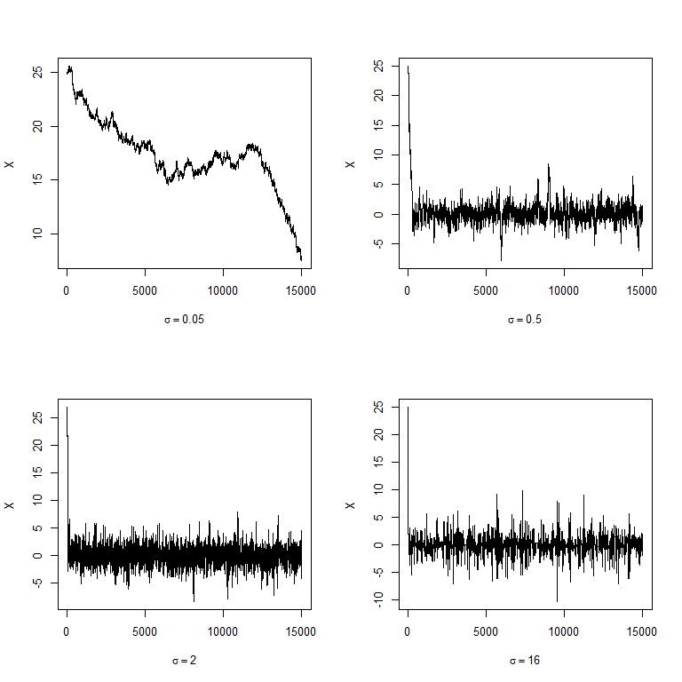

```r
#plot
par(mfrow=c(2,2)) #display 4 graphs together
    rw = cbind(rw1$x, rw2$x, rw3$x, rw4$x)
    for (j in 1:4) {
        plot(rw[,j], type="l",
             xlab=bquote(sigma == .(round(sigma[j],3))),
             ylab="X", ylim=range(rw[,j]) )
    }
```

```r
par(mfrow = c(1,1))  # reset default
```

From the plots we can see the difference in convergence speed resulting from different values of sigma, which tends to be slow when sigma is small and grows larger with sigma.

gelman-rubin method for monitoring convergence for each value of sigma:  
($\hat{R} <1.2$)

```r
seed=0
monitor1=gelman_rubin_monitor(0.05,seed)
monitor2=gelman_rubin_monitor(0.5,seed)
monitor3=gelman_rubin_monitor(2,seed)
monitor4=gelman_rubin_monitor(16,seed)
```

[output not shown]

clear variables:

```r
# remove all at the end:
rm(list=ls())
```

## Exercise 9.7

**Solution:** Here are the functions that we need for this exercise.

```r
# remove all before start:
rm(list=ls())


#function for bivariate sample chain generation:
my_chain_generator = function(N=5000,burn=1000,rho=0.9,mu1=0,mu2=0,sigma1=1,sigma2=1,seed=0){
  set.seed(seed)

  s1 = sqrt(1-rho^2)*sigma1
  s2 = sqrt(1-rho^2)*sigma2

  X = matrix(0, N, 2) # to store the chain
  X[1, ] = c(mu1, mu2) # to initiate
  for (i in 2:N) {
    x2 = X[i-1, 2]
    m1 = mu1 + rho * (x2 - mu2) * sigma1/sigma2
    X[i, 1] = rnorm(1, m1, s1)
    x1 = X[i, 1]
    m2 = mu2 + rho * (x1 - mu1) * sigma2/sigma1
    X[i, 2] = rnorm(1, m2, s2)
  }
  b = burn + 1
  x = X[b:N, ]

  return(list(x=x, X=X))
}

# function for regression model fit and checking residuals for normality and constant variance
model_fit = function(x){
  myfit = lm(x[,2]~x[,1])
  print(myfit)

  par(mfrow=c(2,2),mar=rep(0,4))
  plot(myfit,cex=0.3)
}


Gelman.Rubin <- function(psi) {
  psi <- as.matrix(psi)
  n <- ncol(psi)
  k <- nrow(psi)
  psi.means <- rowMeans(psi) #row means
  B <- n * var(psi.means) #between variance est.
  psi.w <- apply(psi, 1, "var") #within variances
  W <- mean(psi.w) #within est.
  v.hat <- W*(n-1)/n + (B/n) #upper variance est.
  r.hat <- v.hat / W #G-R statistic
  return(r.hat)
}
```

Here we generate data and plot the generated sample after discarding a suitable burn-in sample(1000):

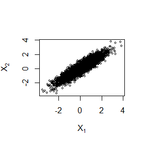

```r
N=5000
mysample = my_chain_generator(N=N)
x = mysample$x
X = mysample$X

# to plot the generated sample after discarding a suitable burn-in sample:
plot(x, main="", cex=.5, xlab=bquote(X[1]), ylab=bquote(X[2]), ylim=range(x[,2]))
```

Now we check the residuals of the model for normality and constant variance:

```r
model_fit(x=x)
```

```
##
## Call:
## lm(formula = x[, 2] ~ x[, 1])
##
## Coefficients:
## (Intercept)       x[, 1]
##    0.003762     0.909222
```

[figure not shown]

gelman-rubin monitoring:

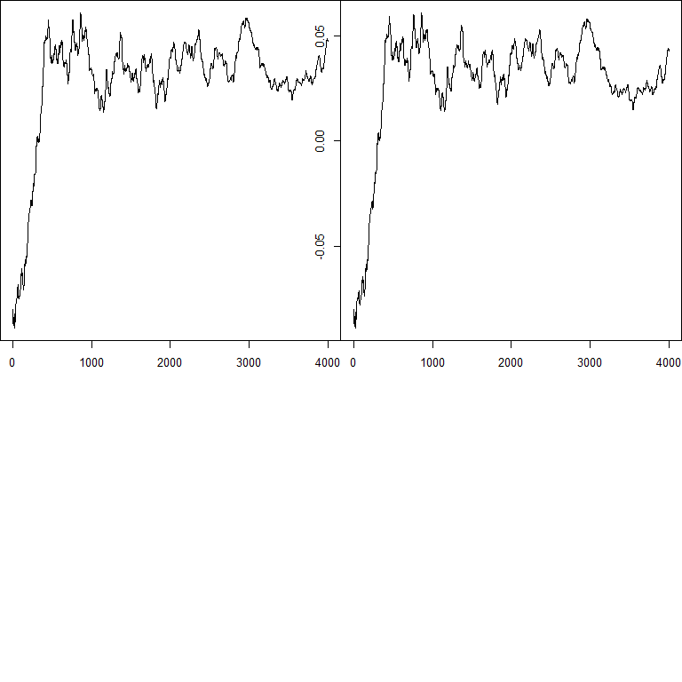

```r
  set.seed(0)

  k <- 2 #number of chains to generate
  n <- N #length of chains
  b <- 1000 #burn-in length

  X=t(X)
  #compute diagnostic statistics
  psi <- t(apply(X, 1, cumsum))
  for (i in 1:nrow(psi))
  psi[i,] <- psi[i,] / (1:ncol(psi))
  #plot psi for the four chains
  par(mfrow=c(2,2),mar=rep(0,4))
  for (i in 1:k)
  plot(psi[i, (b+1):n], type="l",  xlab=i, ylab=bquote(psi))
  par(mfrow=c(1,1)) #restore default
```

[figure not shown]

```r
  #plot the sequence of R-hat statistics
  rhat <- rep(0, n)
  for (j in (b+1):n)
  rhat[j] <- Gelman.Rubin(psi[,1:j])
  plot(rhat[(b+1):n], type="l", xlab="", ylab="R")
  abline(h=1.2, lty=2,col="red")
```

```r
# remove all at the end:
rm(list=ls())
```

# HW8

## Exercise 7.8

Set a random simulation and observe the performance of the three methods above.
Consider the two models:
$$M=a_M+\alpha
X+e_M$$
$$Y=a_Y+\beta M+\gamma
X+e_Y$$
$$e_M,e_Y\ iid\sim
N(0,1)$$
Consider these three set of parameters:
<1> SET1 of Parameters:
$$\alpha =0,\beta =0,\gamma =1$$
<2> SET2 of Parameters:
$$\alpha =0,\beta =1,\gamma =1$$
<3> SET3 of Parameters:
$$\alpha =1,\beta =0,\gamma =1$$

**Solution:** First, here are functions for generating data in this simulation: In this condition we assnign X to distribution N(0,3) and $a_M=a_Y=0$ in this simulation.

```r
# remove all before start:
rm(list=ls())

# function for generation of X, whose distribution is based on our assignment, here is N(0,3)
getX = function(N,myseed=NULL){  # N is length of X
  return( rnorm(N,0,3) )
}

# function for generation of M
getM = function(x,am,alp,myseed=NULL){
  set.seed(myseed)
  N = length(x)
  return( am+alp*x+rnorm(N,0,1) )
}

# function for generation of Y
getY = function(m,x,ay,bet,gam,myseed=NULL){
  set.seed(myseed)
  N = length(m)
  return( ay+bet*m+gam*x+rnorm(N,0,1) )
}
```

And this is the function for test of mediation effects:

```r
library(mediation)
# function for test of mediation effects with package mediation:
mediate_test = function(myalpha=0,mybeta=0,mygamma=1,myseed=NULL){
  x = getX(N = 1e3,myseed = myseed)
  m = getM(x = x,am = 0,alp = myalpha,myseed = myseed)
  y = getY(m = m,x = x,ay = 0,bet = mybeta,gam = mygamma,myseed = myseed)
  dat = matrix(c(x,m,y),ncol=3)
  colnames(dat) = c("x","m","y")

  model_xm = lm(m~x)
  model_xy = lm(y~m+x)
  model_MedEffect = mediate(model_xm,model_xy,treat = 'x',mediator = 'm', sims = 1000,boot = T)

  print(summary(lm(y~m)))
  print(summary(model_MedEffect))
}
```

<1> SET1 of Parameters:  
,,

```r
mediate_test(myalpha = 0,mybeta = 0)
```

```
## Running nonparametric bootstrap
```

```
##
## Call:
## lm(formula = y ~ m)
##
## Residuals:
##      Min       1Q   Median       3Q      Max
## -11.0538  -2.1202  -0.0849   2.2049  11.1874
##
## Coefficients:
##             Estimate Std. Error t value Pr(>|t|)
## (Intercept) -0.01982    0.10078  -0.197    0.844
## m            0.15612    0.09920   1.574    0.116
##
## Residual standard error: 3.185 on 998 degrees of freedom
## Multiple R-squared:  0.002475,   Adjusted R-squared:  0.001476
## F-statistic: 2.477 on 1 and 998 DF,  p-value: 0.1159
##
##
## Causal Mediation Analysis
##
## Nonparametric Bootstrap Confidence Intervals with the Percentile Method
##
##                 Estimate 95% CI Lower 95% CI Upper p-value
## ACME           -0.000406    -0.002193         0.00    0.61
## ADE             1.011244     0.992224         1.03  <2e-16 ***
## Total Effect    1.010838     0.991577         1.03  <2e-16 ***
## Prop. Mediated -0.000402    -0.002164         0.00    0.61
## ---
## Signif. codes:  0 '***' 0.001 '**' 0.01 '*' 0.05 '.' 0.1 ' ' 1
##
## Sample Size Used: 1000
##
##
## Simulations: 1000
```

<2> SET2 of Parameters:  
,,

```r
mediate_test(myalpha = 0,mybeta = 1,myseed = 0)
```

```
## Running nonparametric bootstrap
```

```
##
## Call:
## lm(formula = y ~ m)
##
## Residuals:
##     Min      1Q  Median      3Q     Max
## -8.7675 -2.0532 -0.1084  1.9505  9.9309
##
## Coefficients:
##             Estimate Std. Error t value Pr(>|t|)
## (Intercept)  0.01110    0.09508   0.117    0.907
## m            2.08312    0.09531  21.857   <2e-16 ***
## ---
## Signif. codes:  0 '***' 0.001 '**' 0.01 '*' 0.05 '.' 0.1 ' ' 1
##
## Residual standard error: 3.006 on 998 degrees of freedom
## Multiple R-squared:  0.3237, Adjusted R-squared:  0.323
## F-statistic: 477.7 on 1 and 998 DF,  p-value: < 2.2e-16
##
##
## Causal Mediation Analysis
##
## Nonparametric Bootstrap Confidence Intervals with the Percentile Method
##
##                Estimate 95% CI Lower 95% CI Upper p-value
## ACME             0.0183      -0.0207         0.06    0.37
## ADE              1.0000       1.0000         1.00  <2e-16 ***
## Total Effect     1.0183       0.9793         1.06  <2e-16 ***
## Prop. Mediated   0.0180      -0.0211         0.06    0.37
## ---
## Signif. codes:  0 '***' 0.001 '**' 0.01 '*' 0.05 '.' 0.1 ' ' 1
##
## Sample Size Used: 1000
##
##
## Simulations: 1000
```

Result of test of this set of simulation shows $X\perp M$ indicating $\alpha =0$.

<3> SET3 of Parameters:  
,,

```r
mediate_test(myalpha = 1,mybeta = 0,myseed = 0)
```

```
## Running nonparametric bootstrap
```

```
##
## Call:
## lm(formula = y ~ m)
##
## Residuals:
##        Min         1Q     Median         3Q        Max
## -2.769e-13  5.500e-17  2.820e-16  4.950e-16  9.552e-15
##
## Coefficients:
##              Estimate Std. Error   t value Pr(>|t|)
## (Intercept) 9.830e-17  2.778e-16 3.540e-01    0.723
## m           1.000e+00  8.955e-17 1.117e+16   <2e-16 ***
## ---
## Signif. codes:  0 '***' 0.001 '**' 0.01 '*' 0.05 '.' 0.1 ' ' 1
##
## Residual standard error: 8.783e-15 on 998 degrees of freedom
## Multiple R-squared:      1,  Adjusted R-squared:      1
## F-statistic: 1.247e+32 on 1 and 998 DF,  p-value: < 2.2e-16
##
##
## Causal Mediation Analysis
##
## Nonparametric Bootstrap Confidence Intervals with the Percentile Method
##
##                 Estimate 95% CI Lower 95% CI Upper p-value
## ACME            9.86e-01     9.64e-01         1.01  <2e-16 ***
## ADE            -2.08e-16    -3.04e-16         0.00    0.94
## Total Effect    9.86e-01     9.64e-01         1.01  <2e-16 ***
## Prop. Mediated  1.00e+00     1.00e+00         1.00  <2e-16 ***
## ---
## Signif. codes:  0 '***' 0.001 '**' 0.01 '*' 0.05 '.' 0.1 ' ' 1
##
## Sample Size Used: 1000
##
##
## Simulations: 1000
```

```r
# remove all at the end:
rm(list=ls())
```

## Exercise 7.11

Consider the model:
$$P\left
\{ Y=1|X_1,X_2,X_3 \right \}=expit(a+b_1x_1+b_2x_2+b_3x_3)$$
$$X_1\sim P(1),
X_2\sim Exp(1),
X_3\sim B(1,0.5)$$

**Question 1:**  
<1> Write a function in R to implement the above requirements, with its input $N,b_1,b_2,b_3,f_0$ and output $\alpha$.  
**Solution:**

```r
# remove all before start:
rm(list=ls())


# The following are the functions that are needed for this exercise:

# expit function
expit = function(x){
  1/(1 + exp(-x))
}

# find alpha by solving the equation
find_alpha = function(N,b1,b2,b3,f0,seed=NULL){
  set.seed(seed)
  x1 = rpois(N,1)
  x2 = rexp(N,1)
  x3 = rbinom(N,1,0.5)

  my_pd = function(alpha,b1,b2,b3){
    temp = exp(-alpha-b1*x1-b2*x2-b3*x3)
    temp = 1/(1+temp)
    mean(temp) - f0
  }
  mysolution = uniroot(my_pd,c(-20,10),b1,b2,b3)
  myresult = (round(unlist(mysolution),5)[1:3])

  return(list(result=myresult, root=myresult[[1]]))
}
```

**Question 2:**  
<2> Perform this function with input value $N=10^6,b_1=0,b_2=1,b_3=-1,f_0=0.1,0.01,0.0010.0001.$  
**Solution:**

```r
set.seed(0)
N = 1e6; b1 = 0; b2 = 1; b3 = -1
f0_list = c(1e-1,1e-2,1e-3,1e-4)
alpha_list = numeric(length = length(f0_list))


i=1
for (f0 in f0_list) {
  alpha_list[i] = find_alpha(N=N,b1=b1,b2=b2,b3=b3,f0=f0,seed=NULL)$root
  i=i+1
}

# the result of trying this function is as follows:
print("result output:")
```

```
## [1] "result output:"
```

```r
names(alpha_list) = paste0(" f0=",f0_list)
print(alpha_list)
```

```
##    f0=0.1   f0=0.01  f0=0.001  f0=1e-04
##  -3.16725  -6.07034  -8.70354 -11.32096
```

**Question 2:**  
<3> draw the scatter plot of $f_0$ vs $\alpha$.  
**Solution:**

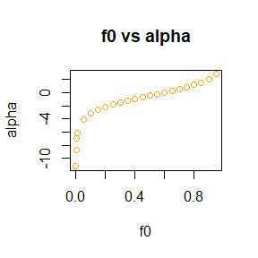

```r
# because I think 4 points are too few for a scatter plot so I added some more points
f0_list = c(c(1e-4,1e-3,5*1e-3,1e-2,5*1e-2),seq(1e-1,0.99,0.05))
alpha_list = numeric(length = length(f0_list))
i=1
for (f0 in f0_list) {
  alpha_list[i] = find_alpha(N=N,b1=b1,b2=b2,b3=b3,f0=f0,seed=NULL)$root
  i=i+1
}

# the scatter plot is:
plot(f0_list,alpha_list,xlab = "f0",ylab = "alpha",main = "f0 vs alpha",col="orange")
```

```r
# remove all at the end:
rm(list=ls())
```

# HW9

## Exercise after class

Suppose $X_1,...,X_n\ iid \sim Exp(\lambda)$. For some reason it’s only known that $X_i$ belongs to some interval ($u_i,v_i$), where $u_i<v_i$ are two non-random known constants. This type of data is called interval-missing data.  
<1> Get MLE by maximizing likelihood function and by EM algorithm and prove they are equal.  
<2> Suppose ($u_i,v_i$), $i=1,...,10$ has observations (11,12),(8,9),(27,28),(13,14),(16,17),(0,1),(23,24),(10,11),(24,25),(2,3). Compute numeric MLE via the 2 methods mentioned above.

**Solution:**
First to consider the likelihood function maximizing method:
$$L(\lambda ) = {\textstyle
\prod_{i=1}^{n}}P_{\lambda }(u_i\le x_i\le v_i)$$
Thus we have:
$$L(\lambda ) = {\textstyle
\prod_{i=1}^{n}}(e^{-\lambda u_i}-e^{-\lambda v_i} )$$
Taking its log:
$$l(\lambda ) = {\textstyle
\sum_{i=1}^{n}}log(e^{-\lambda u_i}-e^{-\lambda v_i})$$
Taking deviation:
$$\frac{\partial
l}{\partial \lambda }l = {\textstyle \sum_{i=1}^{n}}
\frac{-u_ie^{-\lambda u_i}+v_ie^{-\lambda v_i}}{e^{-\lambda
u_i}-e^{-\lambda v_i}}$$
So maximum likelihood occurs at the root of $\lambda$ the equation above.

Here are the functions needed for the first method(maximizing likehood):

```r
# remove all before start:
rm(list=ls())

# function for the deviation of log-likelihood
log_likeh = function(lam,observs){
  myres = 0
  n = nrow(observs)
  for (i in 1:n) {
    ui = observs[i,1]
    vi = observs[i,2]
    myres = myres + log(exp(-lam*ui)-exp(-lam*vi))
  }
  return(myres)
}


# function for the deviation of log-likelihood, its root is MLE:
log_likeh_dev = function(lam,observs){
  myres = 0
  n = nrow(observs)
  for(i in 1:n){
    ui = observs[i,1]
    vi = observs[i,2]
    fac1 = exp(-lam*ui)
    fac2 = exp(-lam*vi)
    myres = myres+(-ui*fac1+vi*fac2)/(fac1-fac2)
  }
  return(myres)
}

# plot the above function to see vaguely where the MLE is and return the root:
getMLE_method1= function(){
  lamlist = seq(0.01,0.25,0.001)
  reslist = numeric(length = length(lamlist))
  for (i in 1:length(lamlist)) {
    reslist[i] = log_likeh_dev(lamlist[i],myobservs)
  }
  # take a peek:
  plot(lamlist,reslist,col="orange",
       xlab = "lambda",ylab = "loglikelihood_dev",
       main = "where the MLE vaguely is"
       )
  abline(h=0,col="red")

  res <- uniroot(log_likeh_dev,observs=myobservs,lower=0.03,upper=0.2)
  return(res$root)
}
```

Data analysis:

```r
# the observations of data:
myobservs = matrix(
  c(11,12, 8,9, 27,28, 13,14, 16,17, 0,1, 23,24, 10,11, 24,25, 2,3),
  ncol=2,byrow = T)

# get mle via method 1
mle1 = getMLE_method1()
```

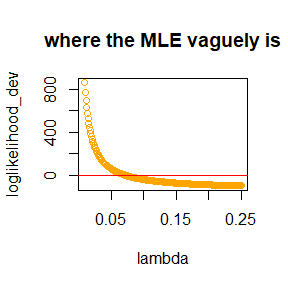

```r
print(paste("For the first method(maximizing likehood), the answer is ",mle1,"."))
```

```
## [1] "For the first method(maximizing likehood), the answer is  0.0719721534069877 ."
```

And the following are the em algorithm(Method 2):

```r
method2 = function(lam0,lam1=5,obs1,obs2,N,eps){ # lam0: initial value; N: max_iterations
  lam2 = lam0

  i=1
  while( abs(lam1-lam2)>=eps ){
    lam1 = lam2
    lam2 = length(obs1)/sum(((lam1*obs1+1)*exp(-lam1*obs1)-(lam1*obs2+1)*exp(-lam1*obs2))/(lam1*(exp(-lam1*obs1)-exp(-lam1*obs2))))
    if(i==N) break
    i<-i+1
  }
  return(lam2)
}


em_sol = method2(lam0=0.5,
                 lam1=5,
                 obs1=myobservs[,1],
                 obs2=myobservs[,2],
                 N=1e5,
                 eps=1e-3)


print(paste("For the first method(maximizing likehood), the answer is ",em_sol,"."))
```

```
## [1] "For the first method(maximizing likehood), the answer is  0.0719735791855385 ."
```

```r
# remove all at the end:
rm(list=ls())
```